# Assignment Six

Celine Brundridge

2023-10-22

## Introduction

Many in the Geographic Information Systems (GIS) world do not check the reliability of their data before plotting it out on a map, submitting it, and then calling it a day. As many readily accept data ripe and ready for mapping, certain sets, intentionally or unintentionally, may carry some mistakes, high variability, and other overlooked elements.

Before data is mapped out in programs such as ArcPro and QGIS, the underlying functions of the data should be examined, cleaned up, and evaluated for optimal geographic representations and statistical analysis. This also strengthens educational experience in the R software and how it can be prepared as a tool in conjunction with the mapping programs.

This vignette in particular walks through a dataset pertaining to race populations and other demographics in New York City, New York among its respective census tracts.

## Load Necessary Libraries

Installing and loading these packages are necessary for data optimization throughout the rest of the script. R packages can be installed by searching it up on the “Packages” tab of RStudio and installing. Then, by using the function “library”, the library of the package can be loaded into the script for use. Short descriptions of each package is detailed next to the corresponding script line below.

```r
#load the libraries needed
library(sf) #Simple Features for R -Handling Geographic Data
library(sp) #Classes and Methods for Spatial Data
library(dplyr) #A Grammar for Data Manipulation
library(rmarkdown) #Notebook Interface to Produce Elegantly Formatted Output
library(knitr) #Elegant, Flexible, and Fast Dynamic Report Generation
```

To know that the package has been installed and the library loaded, there will NOT be an “error/fail” message when the script is run.

## Set Up the Working Environment

Retrieving and setting up your data path is essential in order to work with it in R. To do this, assign the working directory of your data to the folder where the data is using the function “setwd” (set working directory). This data is within a geodatabase.

Make sure NOT to load the last/innermost folder in the path, i.e. the geodatabase folder itself. Instead, load the folder before that, the one that the geodatabase itself is within. The file explorer in your computer typically simplifies its categorizations of files like geodatabases to appear as a folder when it is not just a folder.

```r
#reset the path to where your data is located - do not load the innermost geodatabase folder, load the folder before the geodatabase location
setwd("C:\\Users\\celin\\Documents\\CBGes400_class\\")

#lists folders and files from the working directory - ensures you set the correct path and the data is within
list.dirs() #lists all of the folders from the path
```

```
## [1] "."                      "./assign_products"      "./gpkg_archive"
## [4] "./nyc_geography_v1.gdb" "./stat_tablesonly"      "./VOID"
```

```r
list.files() #lists all of the files in the folder from the path
```

```
##  [1] "“assignment_six_celine_brundridge”.Rmd"
##  [2] "assign_products"
##  [3] "cb_2016_us_county510_500k_nyc.gpkg"
##  [4] "cb_2016_us_tract510_500k_nyc_supp.gpkg"
##  [5] "cb_2016_us_tract510_500k_nyc_wstats.gpkg"
##  [6] "gpkg_archive"
##  [7] "location quotient calculation class assignment.R"
##  [8] "location_quotient_v2_celineb.R"
##  [9] "nyc_geography_v1.gdb"
## [10] "nyc_trct_wlqs.gpkg"
## [11] "RAW_location quotient calculation class assignment.R"
## [12] "stat_tablesonly"
## [13] "student_basic_stats_v2_celineb.R"
## [14] "student_basic_stats_v2_celineb.Rmd"
## [15] "VOID"
```

You can tell if you set the path too deep if no folders or files are listed in the functions following setting up the working directory (list.dirs, list.files), or if an error message appears. Ensure that the “cb_2016_us_tract510_500k_nyc_wstats.gpkg” geopackage folder is listed in the directory after running the script.

## Examine Data for Quality

After setting up the data, the path to the “cb_2016_us_tract510_500k_nyc_wstats.gpkg” geopackage has been located and its contents will be the focus for the remainder of the script. At this point, the data layers and attributes within that geopackage can examined for readiness. To verify the layers, the function “st_layers” will list the available layers within the geopackage. These are spatial layers that contain the features geographically referenced in the map visualization.

```r
#lists the available layers within a geospatial dataset that have already loaded into the RStudio session above
st_layers("cb_2016_us_tract510_500k_nyc_wstats.gpkg")
```

```
## Driver: GPKG
## Available layers:
##                      layer_name geometry_type features fields
## 1 cb_2016_us_tract510_500k_nyc5 Multi Polygon     2164     67
##                                crs_name
## 1 North_America_Albers_Equal_Area_Conic
```

While the layers have now been checked, there is one last step deeper that must be taken for a thorough quality check. The innermost chunk of the data, the attributes within each layer, must be examined. The attributes of each layer provide context and test for both quality control and analytical capability. For example, if we attempted to do a nearest neighbor calculation without looking at the attributes to understand that this data is a multipolygon feature, it would confuse the GIS program and start calculating a loop of incorrect outputs.

For this script, we would like to pull New York City census tract data. This first requires importing the “nyc_tract” data from a specific layer. The only layer pulled that contains the data is “cb_2016_us_tract510_500k_nyc5” within the geopackage by the function “st_read”. The <- symbol is known as an assignment operator, which takes the script on the right (the data source and the specific layer), assigns it to the chosen name on the left of the symbol.

```r
#lists one specific layer within a geospatial dataset with expanded information
nyc_trct<- st_read(dsn= "cb_2016_us_tract510_500k_nyc_wstats.gpkg", layer= "cb_2016_us_tract510_500k_nyc5") #read data (data set name, a layer of your choice)
```

Now, pulling the attributes from the data frame “nyc_trct” can vary in two ways, depending on how thoroughly you would like to comb through the data. First, you could pull out and examine just a short sample of data for a quick visual affirmation. The “head” function will pull out a sample of the FIRST six rows of the layer’s attribute table, with all of the fields listed out. The “tail” function will pull out a sample of the LAST six rows of the layer’s attribute table. Duplicate fields (columns) as well as statistics may appear as this layer has been joined with calculated race demographic statistics from a previous R code script. The tail function in particular is always a good quality check for any extra blank rows. Both functions are good to use together to ensure consistency amongst the fields and values across all of the rows (from the beginning “head” to “tail” end of the table).

```r
head(nyc_trct) #examines a sample of the first few data rows for visual affirmation
```

```
## Simple feature collection with 6 features and 67 fields
## Geometry type: MULTIPOLYGON
## Dimension:     XY
## Bounding box:  xmin: 1735824 ymin: 284988.8 xmax: 1746260 ymax: 294037.6
## Projected CRS: North_America_Albers_Equal_Area_Conic
##   OBJECTID STATEFP COUNTYFP TRACTCE       GEOID  NAME           NAMELSAD MTFCC
## 1        1      36      081  003400 36081003400    34    Census Tract 34 G5020
## 2        2      36      081  003900 36081003900    39    Census Tract 39 G5020
## 3        3      36      081  003600 36081003600    36    Census Tract 36 G5020
## 4        4      36      081  003700 36081003700    37    Census Tract 37 G5020
## 5        5      36      081  003800 36081003800    38    Census Tract 38 G5020
## 6        6      36      081  004001 36081004001 40.01 Census Tract 40.01 G5020
##   FUNCSTAT  ALAND AWATER    INTPTLAT     INTPTLON GEOID_TRACT CNT_BLK_GRP
## 1        S 213987      0 +40.6847731 -073.8581871 36081003400           2
## 2        S 146970      0 +40.7627994 -073.9409316 36081003900           2
```

[output cut: 60 more lines]

```r
tail(nyc_trct) #examines a sample of the last few data rows ("tail" end) for visual affirmation
```

```
## Simple feature collection with 6 features and 67 fields
## Geometry type: MULTIPOLYGON
## Dimension:     XY
## Bounding box:  xmin: 1732994 ymin: 282011.7 xmax: 1749829 ymax: 297992.1
## Projected CRS: North_America_Albers_Equal_Area_Conic
##      OBJECTID STATEFP COUNTYFP TRACTCE       GEOID  NAME           NAMELSAD
## 2159     2159      36      081  108500 36081108500  1085  Census Tract 1085
## 2160     2160      36      081  109300 36081109300  1093  Census Tract 1093
## 2161     2161      36      081  141700 36081141700  1417  Census Tract 1417
## 2162     2162      36      081  006202 36081006202 62.02 Census Tract 62.02
## 2163     2163      36      061  016900 36061016900   169   Census Tract 169
## 2164     2164      36      061  016400 36061016400   164   Census Tract 164
##      MTFCC FUNCSTAT   ALAND AWATER    INTPTLAT     INTPTLON GEOID_TRACT
## 2159 G5020        S  444815      0 +40.7724453 -073.7890720 36081108500
## 2160 G5020        S 1069850 458982 +40.7756127 -073.7704101 36081109300
```

[output cut: 67 more lines]

```r
#or

View(nyc_trct) #another way - views all attribute data in a table on a new tab
```

However, if you want to examine all of the attribute rows, the function “view” allows you to view all of them on a separate, more cohesive table instead of in the console work space of R.

While you observe all of the information outputted in the workspace and table to get a better understanding of the fields that categorize the attribute data, the function “names” will list out all of the names of the fields and the “str” function will list the data types of each field attribute (character/text, integer, number, etc.).

```r
names(nyc_trct) #lists the fields that comprise the columns of the data frame
```

```
##  [1] "OBJECTID"        "STATEFP"         "COUNTYFP"        "TRACTCE"
##  [5] "GEOID"           "NAME"            "NAMELSAD"        "MTFCC"
##  [9] "FUNCSTAT"        "ALAND"           "AWATER"          "INTPTLAT"
## [13] "INTPTLON"        "GEOID_TRACT"     "CNT_BLK_GRP"     "TOT_POP_2017"
## [17] "WHITE"           "BLACK"           "AMI_AN"          "ASIAN"
## [21] "NH_OPI"          "OTHER"           "RACE_TWO"        "RACE_THREE"
## [25] "RACE_GT_THREE"   "Shape_Length"    "Shape_Area"      "fid_2"
## [29] "field_1"         "STATEFP_2"       "COUNTYFP_2"      "TRACTCE_2"
## [33] "GEOID_2"         "NAME_2"          "NAMELSAD_2"      "MTFCC_2"
## [37] "FUNCSTAT_2"      "ALAND_2"         "AWATER_2"        "INTPTLAT_2"
## [41] "INTPTLON_2"      "GEOID_TRACT_2"   "CNT_BLK_GRP_2"   "TOT_POP_2017_2"
## [45] "WHITE_2"         "BLACK_2"         "AMI_AN_2"        "ASIAN_2"
## [49] "NH_OPI_2"        "OTHER_2"         "RACE_TWO_2"      "RACE_THREE_2"
## [53] "RACE_GT_THREE_2" "Shape_Length_2"  "Shape_Area_2"    "OTHER_CMB"
## [57] "WHITE_PCT"       "BLACK_PCT"       "ASIAN_PCT"       "OTHER_CMB_PCT"
## [61] "WHT_OTH_RTO"     "BLK_OTH_RTO"     "ASN_OTH_RTO"     "WHITE_DNS"
## [65] "BLACK_DNS"       "ASIAN_DNS"       "OTHER_CMB_DNS"   "geom"
```

```r
str(nyc_trct) #lists the field data types that comprise the columns of the data frame
```

```
## Classes 'sf' and 'data.frame':   2164 obs. of  68 variables:
##  $ OBJECTID       : num  1 2 3 4 5 6 7 8 9 10 ...
##  $ STATEFP        : chr  "36" "36" "36" "36" ...
##  $ COUNTYFP       : chr  "081" "081" "081" "081" ...
##  $ TRACTCE        : chr  "003400" "003900" "003600" "003700" ...
##  $ GEOID          : chr  "36081003400" "36081003900" "36081003600" "36081003700" ...
##  $ NAME           : chr  "34" "39" "36" "37" ...
##  $ NAMELSAD       : chr  "Census Tract 34" "Census Tract 39" "Census Tract 36" "Census Tract 37" ...
##  $ MTFCC          : chr  "G5020" "G5020" "G5020" "G5020" ...
##  $ FUNCSTAT       : chr  "S" "S" "S" "S" ...
##  $ ALAND          : num  213987 146970 180006 386629 176214 ...
##  $ AWATER         : num  0 0 0 14591 0 ...
##  $ INTPTLAT       : chr  "+40.6847731" "+40.7627994" "+40.6837714" "+40.7624148" ...
##  $ INTPTLON       : chr  "-073.8581871" "-073.9409316" "-073.8568176" "-073.9434494" ...
##  $ GEOID_TRACT    : chr  "36081003400" "36081003900" "36081003600" "36081003700" ...
```

[output cut: 60 more lines]

Listing out the data types in particular is important, in case text data should be changed to integer data, so that when processed by the system, unexpected errors will not occur when combining, merging, or joining data that may look like the same type to the human eye, but is not registered as so by the computer. For example, if the “Asian” was a number data type, but the “NH_OPI” (Native Hawaiian and Oceania Pacific Islander) was a text data type, then combining those two data fields as one representative field would be near impossible.

## Calculate the Location Quotient

How are we going to ensure that a group is actually represented in the geographic parcel, tract, or context? This is where the location quotient comes in. The location quotient situates and local geography with a regional geography - comparing each and thus contextualizing local patterns by calculating how more or less one group is represented or underrepresented. One may think that regionally, each census local tract is expected to look generally the same, but the social processes and contexts make them not the same. Surrounding census tracts influence the census tract. When dealing with a social problem it is not helpful to say that “there is this asian population here and this white population there”, it is better to say that these is a magnitude: “a 6x times higher asian population here than white population next to it”.

```r
raceGroups = c("WHITE", "BLACK", "ASIAN", "OTHER_CMB") #create a list of the four race groups to store in raceGroups
for (i in raceGroups) {
  print(raceGroups[i]) #print the name of the race group in the loop iteration
  print(summary(nyc_trct[[i]])) #print the summary stats of the race group from the data frame in the loop iteration
}
```

```
## [1] NA
##    Min. 1st Qu.  Median    Mean 3rd Qu.    Max.
##       0     467    1258    1692    2391   14516
## [1] NA
##    Min. 1st Qu.  Median    Mean 3rd Qu.    Max.
##     0.0    64.0   325.5   961.9  1548.0 17020.0
## [1] NA
##    Min. 1st Qu.  Median    Mean 3rd Qu.    Max.
##    0.00   68.75  249.00  553.76  736.75 7822.00
## [1] NA
##    Min. 1st Qu.  Median    Mean 3rd Qu.    Max.
##     0.0   228.0   502.5   879.6  1057.2 11895.0
```

Once ran, you will see summary statistics of all four race groups in the console space. This will ensure that there is nothing wrong with the trend of the data from its minimum to its maximum, and any skews can be examined for their intensity, indicating clustering. If this function fails, it may indicate an issue with inconsistent data types, such as text values instead of numeric values.

The location quotient manifests itself as a ratio index explicitly calculated below, following the initial equation comparing the ratio “part” to the “whole”. First, a new function titled “calculate lq” is created that is going to take the line of code right of the assignment operator “<-” and process it in the lines below. The “grp” is the local group of a census tract. The “ttl” is all of the population, or total population in the census tract. The “grp” is the numerator and the “ttl” is the denominator of the part. With those variables defined and appeared on the environment tab under functions, the local proportion in the numerator of the whole equation can be calculated by dividng the grp to the ttl and assigning that result to a new part called “lprp”, or the local proportion. Next, the regional proportion in the denominator of the whole equation can be calculated by dividng the sum of the grp and sum of the ttl, which is essentially first using the function “sum” to add up the population of the local group across all census tracts (grp) and the “sum” to add up the population of all of the population across all census tracts. The division of both of these sums is assigned to a new part called “rprp”, or the regional proportion. With both parts of the whole equation calculated and assigned, the “lprp” and “rprp” can be divided (part to part) to achieve the location quotient. The “return” function essentially closes out the created function (“calculate lq”).

```r
"calculate_lq"<- function(grp, ttl){
  lprp<- grp/ttl #calculates the local proportion (part to the whole).
  rprp<- sum(grp)/sum(ttl) #calculates the regional proportion (part to the whole).
  lq<- lprp/rprp #calculates location quotient (part to part).
  return(lprp/rprp) #return the location quotient.
}
```

With this functions now created, it can be applied to each race group individually. Focusing in on the nyc_trct dataframe using the “attach” function, the location quotient function “calculate lq” will be used on the white population in proportion to the total population of each census tract in 2017. The result of this function calculation will be placed into the data table under the fields “WLQ, BLQ, etc.” The same is done for the other races.

```r
attach(nyc_trct) #Replace what is in the parentheses with the correct columns.
nyc_trct$WLQ<- calculate_lq(WHITE, TOT_POP_2017)
nyc_trct$BLQ<- calculate_lq(BLACK, TOT_POP_2017)
nyc_trct$ALQ<- calculate_lq(ASIAN, TOT_POP_2017)
nyc_trct$OLQ<- calculate_lq(OTHER_CMB, TOT_POP_2017)
detach(nyc_trct)

names(nyc_trct)
```

```
##  [1] "OBJECTID"        "STATEFP"         "COUNTYFP"        "TRACTCE"
##  [5] "GEOID"           "NAME"            "NAMELSAD"        "MTFCC"
##  [9] "FUNCSTAT"        "ALAND"           "AWATER"          "INTPTLAT"
## [13] "INTPTLON"        "GEOID_TRACT"     "CNT_BLK_GRP"     "TOT_POP_2017"
## [17] "WHITE"           "BLACK"           "AMI_AN"          "ASIAN"
## [21] "NH_OPI"          "OTHER"           "RACE_TWO"        "RACE_THREE"
## [25] "RACE_GT_THREE"   "Shape_Length"    "Shape_Area"      "fid_2"
## [29] "field_1"         "STATEFP_2"       "COUNTYFP_2"      "TRACTCE_2"
## [33] "GEOID_2"         "NAME_2"          "NAMELSAD_2"      "MTFCC_2"
## [37] "FUNCSTAT_2"      "ALAND_2"         "AWATER_2"        "INTPTLAT_2"
## [41] "INTPTLON_2"      "GEOID_TRACT_2"   "CNT_BLK_GRP_2"   "TOT_POP_2017_2"
## [45] "WHITE_2"         "BLACK_2"         "AMI_AN_2"        "ASIAN_2"
## [49] "NH_OPI_2"        "OTHER_2"         "RACE_TWO_2"      "RACE_THREE_2"
## [53] "RACE_GT_THREE_2" "Shape_Length_2"  "Shape_Area_2"    "OTHER_CMB"
## [57] "WHITE_PCT"       "BLACK_PCT"       "ASIAN_PCT"       "OTHER_CMB_PCT"
## [61] "WHT_OTH_RTO"     "BLK_OTH_RTO"     "ASN_OTH_RTO"     "WHITE_DNS"
## [65] "BLACK_DNS"       "ASIAN_DNS"       "OTHER_CMB_DNS"   "geom"
## [69] "WLQ"             "BLQ"             "ALQ"             "OLQ"
```

Without this “calculate lq” function set, it is much harder to solve these conditional and repetitive calculations for each race. The “detach” function will “defocus” from the “attached” dataframe. Note the attach and detach functions. The “attach” function essentially alerts RStudio that the selected data frame is the one that will be used/referenced to from this point on, so that you do not have to write “nyc_trct$” before each field/race group listed on the right. The “detach” function essentially alerts RStudio that you are done using this data frame. While use of these functions are controversial in the R community, if there is only one main data frame that is being utilized in the program, than it can be a useful tool for streamlined coding. If there are multiple data frames, it can be difficult to keep track of which data frame is attached to the environment, RStudio can exhibit confusion if you do not properly keep track, and then errors unavoidably occur.

The “names” function lists the attributes by inserting only what is needed in the parentheses, great for determining if the variables “WLQ, etc.” were actually created and now a part of the attributes in the layer. The variables assigned are short for [race] location quotient (_LQ).

```r
#List the attributes by inserting what is needed in the parentheses.
names(nyc_trct)
```

```
##  [1] "OBJECTID"        "STATEFP"         "COUNTYFP"        "TRACTCE"
##  [5] "GEOID"           "NAME"            "NAMELSAD"        "MTFCC"
##  [9] "FUNCSTAT"        "ALAND"           "AWATER"          "INTPTLAT"
## [13] "INTPTLON"        "GEOID_TRACT"     "CNT_BLK_GRP"     "TOT_POP_2017"
## [17] "WHITE"           "BLACK"           "AMI_AN"          "ASIAN"
## [21] "NH_OPI"          "OTHER"           "RACE_TWO"        "RACE_THREE"
## [25] "RACE_GT_THREE"   "Shape_Length"    "Shape_Area"      "fid_2"
## [29] "field_1"         "STATEFP_2"       "COUNTYFP_2"      "TRACTCE_2"
## [33] "GEOID_2"         "NAME_2"          "NAMELSAD_2"      "MTFCC_2"
## [37] "FUNCSTAT_2"      "ALAND_2"         "AWATER_2"        "INTPTLAT_2"
## [41] "INTPTLON_2"      "GEOID_TRACT_2"   "CNT_BLK_GRP_2"   "TOT_POP_2017_2"
## [45] "WHITE_2"         "BLACK_2"         "AMI_AN_2"        "ASIAN_2"
## [49] "NH_OPI_2"        "OTHER_2"         "RACE_TWO_2"      "RACE_THREE_2"
## [53] "RACE_GT_THREE_2" "Shape_Length_2"  "Shape_Area_2"    "OTHER_CMB"
## [57] "WHITE_PCT"       "BLACK_PCT"       "ASIAN_PCT"       "OTHER_CMB_PCT"
## [61] "WHT_OTH_RTO"     "BLK_OTH_RTO"     "ASN_OTH_RTO"     "WHITE_DNS"
## [65] "BLACK_DNS"       "ASIAN_DNS"       "OTHER_CMB_DNS"   "geom"
## [69] "WLQ"             "BLQ"             "ALQ"             "OLQ"
```

After running, all of the attributes are shown. if the four additional location quotient groups calculated previously do not appear in the console space than there may be an error in the function creation and/or the function use.

While typically the data visualization would be left to the more specialized software such as ArcPro and QGIS for analysis, for quality checking purposes RStudio can quickly draw up a plot in the data to see if it simply looks appropriate or as envisioned. The “plot” function will display a geometric visual/map of the specified field “WLQ” and so forth to determine if the location quotients were calculated correctly, in which you will see patterns/densities on the map. Similar to the previous code chunks, the “summary” function here is just applied to the location quotient groups. The histogram function “hist” creates a histogram displaying the the distribution of the location quotient among each race, the x-axis range broken up into 50 numerical categories which was specified with “breaks= 50”. The same is done below for the other three race groups to create three more histograms.

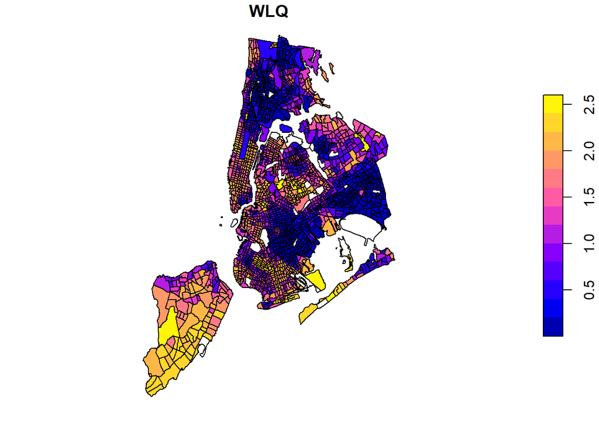

```r
plot(nyc_trct["WLQ"]) #plotted thematic map of the LQs to view the geographic distribution
```

```r
summary(nyc_trct$WLQ) #printed summary statistics of a race group LW to review similar to above chunks
```

```
##    Min. 1st Qu.  Median    Mean 3rd Qu.    Max.    NA's
##  0.0000  0.3379  0.9191  1.0073  1.6389  2.4155      37
```

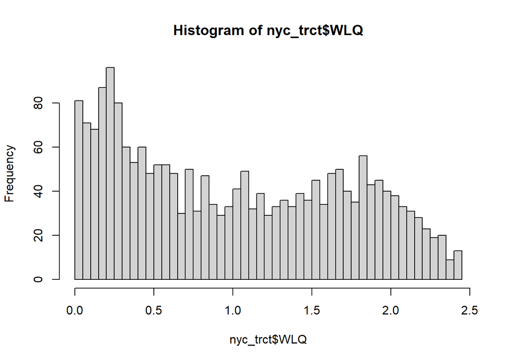

```r
hist(nyc_trct$WLQ, breaks= 50) #plotted histogram to examine the frequency distribution with the geographic distribution
```

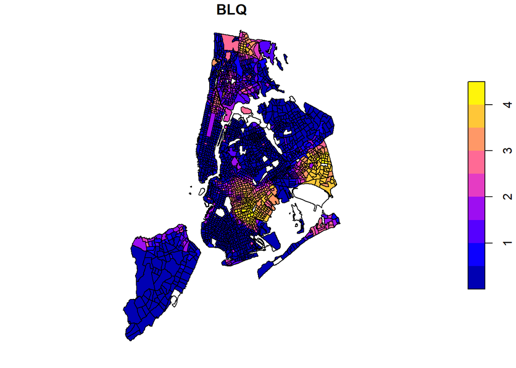

```r
plot(nyc_trct["BLQ"]) #same as above, but different race groups
```

```r
summary(nyc_trct$BLQ)
```

```
##    Min. 1st Qu.  Median    Mean 3rd Qu.    Max.    NA's
## 0.00000 0.08637 0.38712 1.05263 1.75672 4.24940      37
```

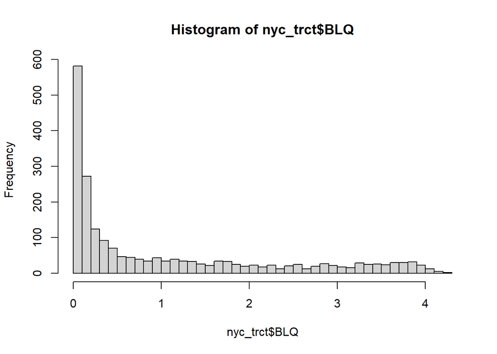

```r
hist(nyc_trct$BLQ, breaks= 50)
```

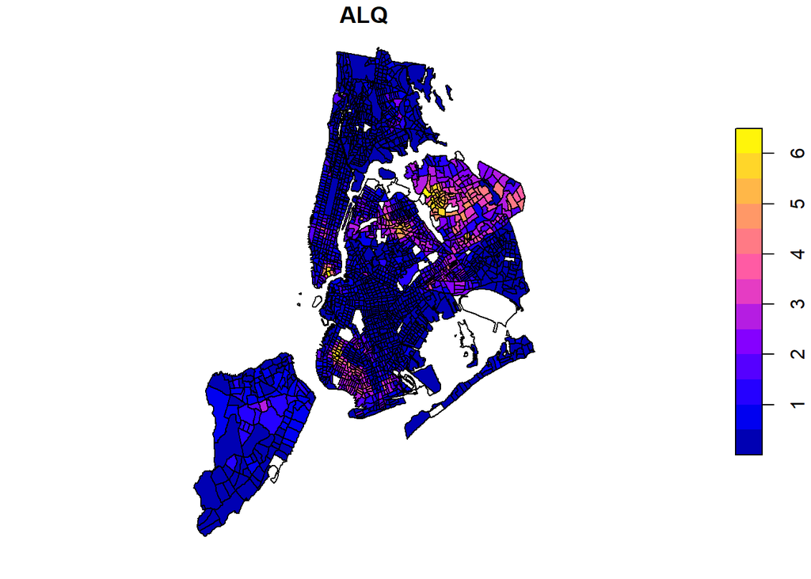

```r
plot(nyc_trct["ALQ"]) ##same as above, but different race groups
```

```r
summary(nyc_trct$ALQ)
```

```
##    Min. 1st Qu.  Median    Mean 3rd Qu.    Max.    NA's
##  0.0000  0.1641  0.5275  1.0106  1.4085  6.3821      37
```

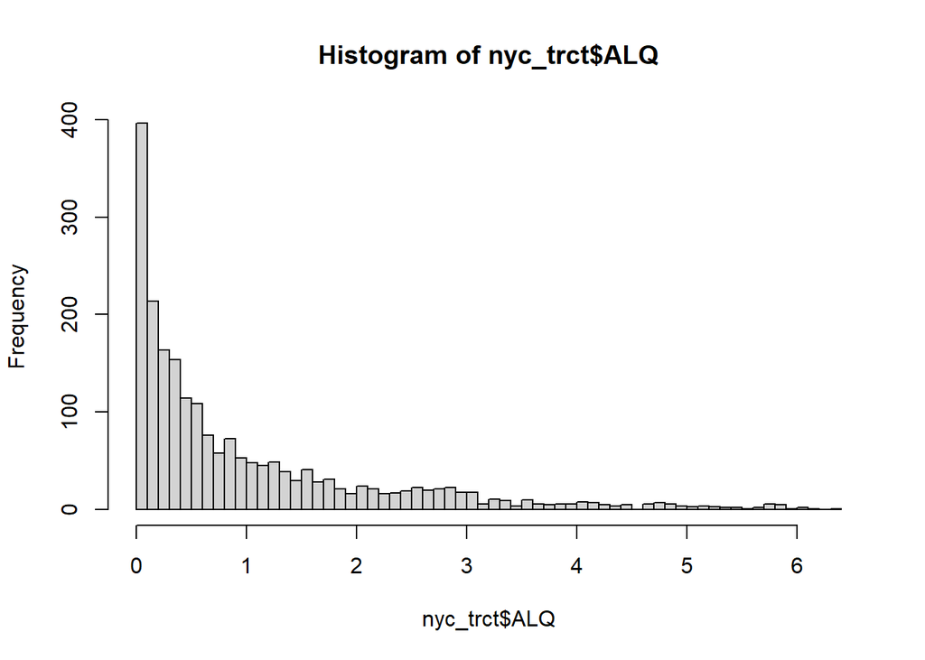

```r
hist(nyc_trct$ALQ, breaks= 50)
```

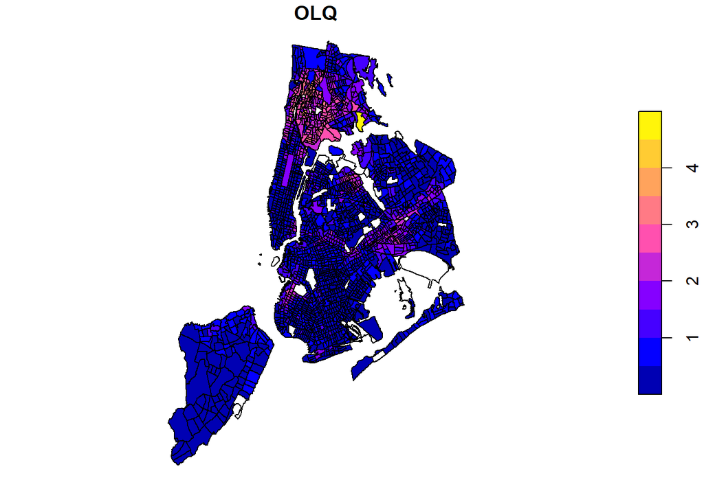

```r
plot(nyc_trct["OLQ"]) ##same as above, but different race groups
```

```r
summary(nyc_trct$OLQ)
```

```
##    Min. 1st Qu.  Median    Mean 3rd Qu.    Max.    NA's
##  0.0000  0.3618  0.6603  0.9218  1.2465  4.6467      37
```

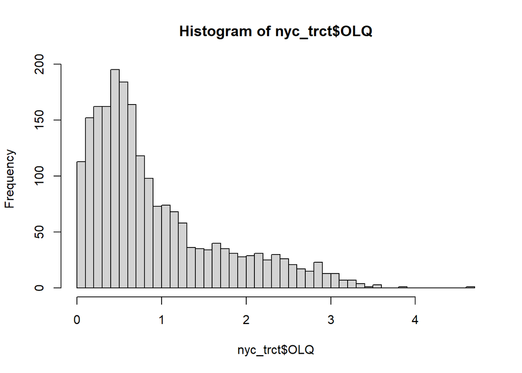

```r
hist(nyc_trct$OLQ, breaks= 50)
```

If you do not see the map patterns or densities then the calculations above were executed incorrectly. Another note is to be mindful that that the color ramps for LQ may be flipped when analyzing the map densities. Our eyes tend to focus on dark areas as the most concentrated by the simple plotting function of R may not account for that human insight. The summaries are a great tool to check if the data came out reasonably. You can tell that it did not if the maximum value does not go above 1. The location quotient when displayed on map makes the histogram smoother as peaks and valleys smooth out–you do not have to worry about those being overlooked or some hidden pattern lost in there. In the histograms, there are definitely signs of greater skew with longer tails among the minority groups.

## Data Preparation for Exportation

With all of the statistics calculated, in the final step before the data is ready for use in GIS mapping program such as ArcPro and QGIS, there are a couple of formatting parameters to be addressed. This is a large amount of data that will be output from program to program, so it is always beneficial to compartmentalize it. To do this, a new data frame will be created using the assignment operator “<-” called “nyc_trct_df”, to convert the geographic data of “nyc_tract” to a simple data frame. This will ensure all function on the data can work. It can save data to link it with the layer when in the GIS because when you try to work on just the attribute table in the data frame there can be confusion in the program.

```r
#Converting the geographic dataframe to a standard dataframe
nyc_trct_df<- as.data.frame(nyc_trct)

#Remove the geometry by deleting the column. In the vignette, describe why this task is being done.
nyc_trct_df$Shape<- NULL
```

To ensure no inconsistencies in the data with pesky N/A’s (not available data), and inf’s (infinity), they will all be converted to 0. It is reasonable to change all of these to 0 based on the context that the census tracts with those values are those with no actual population residing within their bounds. With other datasets, context is important in determining how to deal with these values. To convert these to 0, the combined “c” group consisting of our new location quotient calculations pulled from the simple dataframe will be examined for their “is.na” values, or for those not available. Then, each of these groups with any NA data (that fall true under the condition that it “is.na”) will be reassigned from NA to 0. The same is done for the infinity values, except that the “is.na” condition is replaced with the “is.infinite” condition.

```r
nyc_trct_df[c('WLQ', 'BLQ', 'ALQ', 'OLQ')][is.na(nyc_trct_df[c('WLQ', 'BLQ', 'ALQ', 'OLQ')])]<- 0
nyc_trct_df[is.na(nyc_trct_df$WLQ)]= 0
nyc_trct_df[is.na(nyc_trct_df$BLQ)]= 0
nyc_trct_df[is.na(nyc_trct_df$ALQ)]= 0
nyc_trct_df[is.na(nyc_trct_df$OLQ)]= 0

nyc_trct_df[is.infinite(nyc_trct_df$WLQ)]= 0
nyc_trct_df[is.infinite(nyc_trct_df$BLQ)]= 0
nyc_trct_df[is.infinite(nyc_trct_df$ALQ)]= 0
nyc_trct_df[is.infinite(nyc_trct_df$OLQ)]= 0
```

The last component before exportation would be to subset the demographic race group data using the “subset” function, and shrink the data down to only those fields needed, which are the fields that we created while calculating the location quotient, and then the “GEOID” (geographic identifier) field, which is a unique feature identifier, essential for the geographic linkage in mapping. Without it, the data would no longer be spatial data–just data. This sub-setting will be important in future steps on the GIS program as only the calculated location quotients will be necessary to merge onto the census tract geopackage “cb_2016_us_tract510_500k_nyc_wstats.gpkg”.

```r
lq_data<- subset(nyc_trct_df, select= c(GEOID, WLQ, BLQ, ALQ, OLQ))

st_write(lq_data, "nyc_trct_wlqs.gpkg", layer= "lq_data", delete_dsn = TRUE)
```

```
## Deleting source `nyc_trct_wlqs.gpkg' using driver `GPKG'
## Writing layer `lq_data' to data source `nyc_trct_wlqs.gpkg' using driver `GPKG'
## Writing 2164 features with 5 fields without geometries.
```

To ensure successful exportation, a new .gpkg file in your directory should appear called “nyc_trct_wlqs.gpkg”.

By availing yourself of the capabilities within RStudio to establish, investigate, enhance, visualize, and scrutinize the intricate nuances of your data, you can instill a profound sense of confidence in the methodological soundness and data integrity when integrating it into a Geographic Information System. This robust foundation will empower you to make well-informed decisions and yield outstanding outcomes in your work.